# W3cubDocs

/Qt

# QImage Class

The QImage class provides a hardware-independent image representation that allows direct access to the pixel data, and can be used as a paint device. More...

| Header: | #include <QImage> |
| --- | --- |
| CMake: | find_package(Qt6 COMPONENTS Gui REQUIRED) target_link_libraries(mytarget PRIVATE Qt6::Gui) |
| qmake: | QT += gui |
| Inherits: | QPaintDevice |

- [List of all members, including inherited members](https://doc.qt.io/qt-6.2/qimage-members.html)

**Note:** All functions in this class are reentrant.

## Public Types

| enum | **Format** { Format_Invalid, Format_Mono, Format_MonoLSB, Format_Indexed8, Format_RGB32, …, Format_RGBA32FPx4_Premultiplied } |
| --- | --- |
| enum | **InvertMode** { InvertRgb, InvertRgba } |

## Public Functions

|  | **QImage**(QImage &&*other*) |
| --- | --- |
|  | **QImage**(const QImage &*image*) |
|  | **QImage**(const QString &*fileName*, const char **format* = nullptr) |
|  | **QImage**(const char *const [] *xpm*) |
|  | **QImage**(const uchar **data*, int *width*, int *height*, qsizetype *bytesPerLine*, QImage::Format *format*, QImageCleanupFunction *cleanupFunction* = nullptr, void **cleanupInfo* = nullptr) |
|  | **QImage**(uchar **data*, int *width*, int *height*, qsizetype *bytesPerLine*, QImage::Format *format*, QImageCleanupFunction *cleanupFunction* = nullptr, void **cleanupInfo* = nullptr) |
|  | **QImage**(const uchar **data*, int *width*, int *height*, QImage::Format *format*, QImageCleanupFunction *cleanupFunction* = nullptr, void **cleanupInfo* = nullptr) |
|  | **QImage**(uchar **data*, int *width*, int *height*, QImage::Format *format*, QImageCleanupFunction *cleanupFunction* = nullptr, void **cleanupInfo* = nullptr) |
|  | **QImage**(int *width*, int *height*, QImage::Format *format*) |
|  | **QImage**(const QSize &*size*, QImage::Format *format*) |
|  | **QImage**() |
| QImage & | **operator=**(QImage &&*other*) |
| QImage & | **operator=**(const QImage &*image*) |
| virtual | **~QImage**() |
| bool | **allGray**() const |
| void | **applyColorTransform**(const QColorTransform &*transform*) |
| int | **bitPlaneCount**() const |
| uchar * | **bits**() |
| const uchar * | **bits**() const |
| qsizetype | **bytesPerLine**() const |
| qint64 | **cacheKey**() const |
| QRgb | **color**(int *i*) const |
| int | **colorCount**() const |
| QColorSpace | **colorSpace**() const |
| QList<QRgb> | **colorTable**() const |
| const uchar * | **constBits**() const |
| const uchar * | **constScanLine**(int *i*) const |
| void | **convertTo**(QImage::Format *format*, Qt::ImageConversionFlags *flags* = Qt::AutoColor) |
| void | **convertToColorSpace**(const QColorSpace &*colorSpace*) |
| QImage | **convertToFormat**(QImage::Format *format*, Qt::ImageConversionFlags *flags* = Qt::AutoColor) const & |
| QImage | **convertToFormat**(QImage::Format *format*, Qt::ImageConversionFlags *flags* = Qt::AutoColor) && |

[output cut: 81 more lines]

## Static Public Members

| QImage | **fromData**(QByteArrayView *data*, const char **format* = nullptr) |
| --- | --- |
| QImage | **fromData**(const uchar **data*, int *size*, const char **format* = nullptr) |
| QImage | **fromData**(const QByteArray &*data*, const char **format* = nullptr) |
| QImage | **fromHBITMAP**(HBITMAP *hbitmap*) |
| QImage | **fromHICON**(HICON *icon*) |
| QImage::Format | **toImageFormat**(QPixelFormat *format*) |
| QPixelFormat | **toPixelFormat**(QImage::Format *format*) |
| QTransform | **trueMatrix**(const QTransform &*matrix*, int *width*, int *height*) |

## Related Non-Members

|  | **QImageCleanupFunction** |
| --- | --- |
| QDataStream & | **operator<<**(QDataStream &*stream*, const QImage &*image*) |
| QDataStream & | **operator>>**(QDataStream &*stream*, QImage &*image*) |

## Detailed Description

Qt provides four classes for handling image data: QImage, QPixmap, QBitmap and QPicture. QImage is designed and optimized for I/O, and for direct pixel access and manipulation, while QPixmap is designed and optimized for showing images on screen. QBitmap is only a convenience class that inherits QPixmap, ensuring a depth of 1. Finally, the QPicture class is a paint device that records and replays QPainter commands.

Because QImage is a QPaintDevice subclass, QPainter can be used to draw directly onto images. When using QPainter on a QImage, the painting can be performed in another thread than the current GUI thread.

The QImage class supports several image formats described by the Format enum. These include monochrome, 8-bit, 32-bit and alpha-blended images which are available in all versions of Qt 4.x.

QImage provides a collection of functions that can be used to obtain a variety of information about the image. There are also several functions that enables transformation of the image.

QImage objects can be passed around by value since the QImage class uses implicit data sharing. QImage objects can also be streamed and compared.

**Note:** If you would like to load QImage objects in a static build of Qt, refer to the Plugin HowTo.

**Warning:** Painting on a QImage with the format QImage::Format_Indexed8 is not supported.

### Reading and Writing Image Files

QImage provides several ways of loading an image file: The file can be loaded when constructing the QImage object, or by using the load() or loadFromData() functions later on. QImage also provides the static fromData() function, constructing a QImage from the given data. When loading an image, the file name can either refer to an actual file on disk or to one of the application's embedded resources. See The Qt Resource System overview for details on how to embed images and other resource files in the application's executable.

Simply call the save() function to save a QImage object.

The complete list of supported file formats are available through the QImageReader::supportedImageFormats() and QImageWriter::supportedImageFormats() functions. New file formats can be added as plugins. By default, Qt supports the following formats:

| Format | Description | Qt's support |
| --- | --- | --- |
| BMP | Windows Bitmap | Read/write |
| GIF | Graphic Interchange Format (optional) | Read |
| JPG | Joint Photographic Experts Group | Read/write |
| JPEG | Joint Photographic Experts Group | Read/write |
| PNG | Portable Network Graphics | Read/write |
| PBM | Portable Bitmap | Read |
| PGM | Portable Graymap | Read |
| PPM | Portable Pixmap | Read/write |
| XBM | X11 Bitmap | Read/write |
| XPM | X11 Pixmap | Read/write |

### Image Information

QImage provides a collection of functions that can be used to obtain a variety of information about the image:

|  | Available Functions |
| --- | --- |
| Geometry | The size(), width(), height(), dotsPerMeterX(), and dotsPerMeterY() functions provide information about the image size and aspect ratio. The rect() function returns the image's enclosing rectangle. Th… |
| Colors | The color of a pixel can be retrieved by passing its coordinates to the pixel() function. The pixel() function returns the color as a QRgb value independent of the image's format. In case of monochrom… |
| Text | The text() function returns the image text associated with the given text key. An image's text keys can be retrieved using the textKeys() function. Use the setText() function to alter an image's text. |
| Low-level information | The depth() function returns the depth of the image. The supported depths are 1 (monochrome), 8, 16, 24 and 32 bits. The bitPlaneCount() function tells how many of those bits that are used. For more i… |

### Pixel Manipulation

The functions used to manipulate an image's pixels depend on the image format. The reason is that monochrome and 8-bit images are index-based and use a color lookup table, while 32-bit images store ARGB values directly. For more information on image formats, see the Image Formats section.

In case of a 32-bit image, the setPixel() function can be used to alter the color of the pixel at the given coordinates to any other color specified as an ARGB quadruplet. To make a suitable QRgb value, use the qRgb() (adding a default alpha component to the given RGB values, i.e. creating an opaque color) or qRgba() function. For example:

32-bit

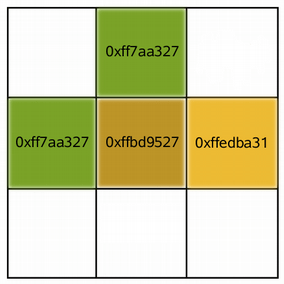

```
QImage image(3, 3, QImage::Format_RGB32);
QRgb value;

value = qRgb(189, 149, 39); // 0xffbd9527
image.setPixel(1, 1, value);

value = qRgb(122, 163, 39); // 0xff7aa327
image.setPixel(0, 1, value);
image.setPixel(1, 0, value);

value = qRgb(237, 187, 51); // 0xffedba31
image.setPixel(2, 1, value);
```

In case of a 8-bit and monchrome images, the pixel value is only an index from the image's color table. So the setPixel() function can only be used to alter the color of the pixel at the given coordinates to a predefined color from the image's color table, i.e. it can only change the pixel's index value. To alter or add a color to an image's color table, use the setColor() function.

An entry in the color table is an ARGB quadruplet encoded as an QRgb value. Use the qRgb() and qRgba() functions to make a suitable QRgb value for use with the setColor() function. For example:

8-bit

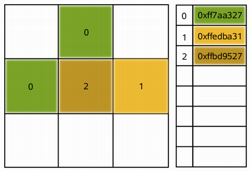

```
QImage image(3, 3, QImage::Format_Indexed8);
QRgb value;

value = qRgb(122, 163, 39); // 0xff7aa327
image.setColor(0, value);

value = qRgb(237, 187, 51); // 0xffedba31
image.setColor(1, value);

value = qRgb(189, 149, 39); // 0xffbd9527
image.setColor(2, value);

image.setPixel(0, 1, 0);
image.setPixel(1, 0, 0);
image.setPixel(1, 1, 2);
image.setPixel(2, 1, 1);
```

For images with more than 8-bit per color-channel. The methods setPixelColor() and pixelColor() can be used to set and get with QColor values.

QImage also provide the scanLine() function which returns a pointer to the pixel data at the scanline with the given index, and the bits() function which returns a pointer to the first pixel data (this is equivalent to `scanLine(0)`).

### Image Formats

Each pixel stored in a QImage is represented by an integer. The size of the integer varies depending on the format. QImage supports several image formats described by the Format enum.

Monochrome images are stored using 1-bit indexes into a color table with at most two colors. There are two different types of monochrome images: big endian (MSB first) or little endian (LSB first) bit order.

8-bit images are stored using 8-bit indexes into a color table, i.e. they have a single byte per pixel. The color table is a QList<QRgb>, and the QRgb typedef is equivalent to an unsigned int containing an ARGB quadruplet on the format 0xAARRGGBB.

32-bit images have no color table; instead, each pixel contains an QRgb value. There are three different types of 32-bit images storing RGB (i.e. 0xffRRGGBB), ARGB and premultiplied ARGB values respectively. In the premultiplied format the red, green, and blue channels are multiplied by the alpha component divided by 255.

An image's format can be retrieved using the format() function. Use the convertToFormat() functions to convert an image into another format. The allGray() and isGrayscale() functions tell whether a color image can safely be converted to a grayscale image.

### Image Transformations

QImage supports a number of functions for creating a new image that is a transformed version of the original: The createAlphaMask() function builds and returns a 1-bpp mask from the alpha buffer in this image, and the createHeuristicMask() function creates and returns a 1-bpp heuristic mask for this image. The latter function works by selecting a color from one of the corners, then chipping away pixels of that color starting at all the edges.

The mirrored() function returns a mirror of the image in the desired direction, the scaled() returns a copy of the image scaled to a rectangle of the desired measures, and the rgbSwapped() function constructs a BGR image from a RGB image.

The scaledToWidth() and scaledToHeight() functions return scaled copies of the image.

The transformed() function returns a copy of the image that is transformed with the given transformation matrix and transformation mode: Internally, the transformation matrix is adjusted to compensate for unwanted translation, i.e. transformed() returns the smallest image containing all transformed points of the original image. The static trueMatrix() function returns the actual matrix used for transforming the image.

There are also functions for changing attributes of an image in-place:

| Function | Description |
| --- | --- |
| setDotsPerMeterX() | Defines the aspect ratio by setting the number of pixels that fit horizontally in a physical meter. |
| setDotsPerMeterY() | Defines the aspect ratio by setting the number of pixels that fit vertically in a physical meter. |
| fill() | Fills the entire image with the given pixel value. |
| invertPixels() | Inverts all pixel values in the image using the given InvertMode value. |
| setColorTable() | Sets the color table used to translate color indexes. Only monochrome and 8-bit formats. |
| setColorCount() | Resizes the color table. Only monochrome and 8-bit formats. |

**See also** QImageReader, QImageWriter, QPixmap, QSvgRenderer, [Image Composition Example](https://doc.qt.io/qt-6.2/qtwidgets-painting-imagecomposition-example.html), [Image Viewer Example](https://doc.qt.io/qt-6.2/qtwidgets-widgets-imageviewer-example.html), [Scribble Example](https://doc.qt.io/qt-6.2/qtwidgets-widgets-scribble-example.html), and [Pixelator Example](https://doc.qt.io/qt-6.2/qtwidgets-itemviews-pixelator-example.html).

## Member Type Documentation

### enum QImage::Format

The following image formats are available in Qt. See the notes after the table.

| Constant | Value | Description |
| --- | --- | --- |
| `QImage::Format_Invalid` | `0` | The image is invalid. |
| `QImage::Format_Mono` | `1` | The image is stored using 1-bit per pixel. Bytes are packed with the most significant bit (MSB) first. |
| `QImage::Format_MonoLSB` | `2` | The image is stored using 1-bit per pixel. Bytes are packed with the less significant bit (LSB) first. |
| `QImage::Format_Indexed8` | `3` | The image is stored using 8-bit indexes into a colormap. |
| `QImage::Format_RGB32` | `4` | The image is stored using a 32-bit RGB format (0xffRRGGBB). |
| `QImage::Format_ARGB32` | `5` | The image is stored using a 32-bit ARGB format (0xAARRGGBB). |
| `QImage::Format_ARGB32_Premultiplied` | `6` | The image is stored using a premultiplied 32-bit ARGB format (0xAARRGGBB), i.e. the red, green, and blue channels are multiplied by the alpha component divided by 255. (If RR, GG, or BB has a higher v… |
| `QImage::Format_RGB16` | `7` | The image is stored using a 16-bit RGB format (5-6-5). |
| `QImage::Format_ARGB8565_Premultiplied` | `8` | The image is stored using a premultiplied 24-bit ARGB format (8-5-6-5). |
| `QImage::Format_RGB666` | `9` | The image is stored using a 24-bit RGB format (6-6-6). The unused most significant bits is always zero. |
| `QImage::Format_ARGB6666_Premultiplied` | `10` | The image is stored using a premultiplied 24-bit ARGB format (6-6-6-6). |
| `QImage::Format_RGB555` | `11` | The image is stored using a 16-bit RGB format (5-5-5). The unused most significant bit is always zero. |
| `QImage::Format_ARGB8555_Premultiplied` | `12` | The image is stored using a premultiplied 24-bit ARGB format (8-5-5-5). |
| `QImage::Format_RGB888` | `13` | The image is stored using a 24-bit RGB format (8-8-8). |
| `QImage::Format_RGB444` | `14` | The image is stored using a 16-bit RGB format (4-4-4). The unused bits are always zero. |
| `QImage::Format_ARGB4444_Premultiplied` | `15` | The image is stored using a premultiplied 16-bit ARGB format (4-4-4-4). |
| `QImage::Format_RGBX8888` | `16` | The image is stored using a 32-bit byte-ordered RGB(x) format (8-8-8-8). This is the same as the Format_RGBA8888 except alpha must always be 255. (added in Qt 5.2) |
| `QImage::Format_RGBA8888` | `17` | The image is stored using a 32-bit byte-ordered RGBA format (8-8-8-8). Unlike ARGB32 this is a byte-ordered format, which means the 32bit encoding differs between big endian and little endian architec… |
| `QImage::Format_RGBA8888_Premultiplied` | `18` | The image is stored using a premultiplied 32-bit byte-ordered RGBA format (8-8-8-8). (added in Qt 5.2) |
| `QImage::Format_BGR30` | `19` | The image is stored using a 32-bit BGR format (x-10-10-10). (added in Qt 5.4) |
| `QImage::Format_A2BGR30_Premultiplied` | `20` | The image is stored using a 32-bit premultiplied ABGR format (2-10-10-10). (added in Qt 5.4) |
| `QImage::Format_RGB30` | `21` | The image is stored using a 32-bit RGB format (x-10-10-10). (added in Qt 5.4) |
| `QImage::Format_A2RGB30_Premultiplied` | `22` | The image is stored using a 32-bit premultiplied ARGB format (2-10-10-10). (added in Qt 5.4) |
| `QImage::Format_Alpha8` | `23` | The image is stored using an 8-bit alpha only format. (added in Qt 5.5) |
| `QImage::Format_Grayscale8` | `24` | The image is stored using an 8-bit grayscale format. (added in Qt 5.5) |
| `QImage::Format_Grayscale16` | `28` | The image is stored using an 16-bit grayscale format. (added in Qt 5.13) |
| `QImage::Format_RGBX64` | `25` | The image is stored using a 64-bit halfword-ordered RGB(x) format (16-16-16-16). This is the same as the Format_RGBA64 except alpha must always be 65535. (added in Qt 5.12) |
| `QImage::Format_RGBA64` | `26` | The image is stored using a 64-bit halfword-ordered RGBA format (16-16-16-16). (added in Qt 5.12) |
| `QImage::Format_RGBA64_Premultiplied` | `27` | The image is stored using a premultiplied 64-bit halfword-ordered RGBA format (16-16-16-16). (added in Qt 5.12) |
| `QImage::Format_BGR888` | `29` | The image is stored using a 24-bit BGR format. (added in Qt 5.14) |
| `QImage::Format_RGBX16FPx4` | `30` | The image is stored using a 4 16-bit halfword floating point RGBx format (16FP-16FP-16FP-16FP). This is the same as the Format_RGBA16FPx4 except alpha must always be 1.0. (added in Qt 6.2) |
| `QImage::Format_RGBA16FPx4` | `31` | The image is stored using a 4 16-bit halfword floating point RGBA format (16FP-16FP-16FP-16FP). (added in Qt 6.2) |
| `QImage::Format_RGBA16FPx4_Premultiplied` | `32` | The image is stored using a premultiplied 4 16-bit halfword floating point RGBA format (16FP-16FP-16FP-16FP). (added in Qt 6.2) |
| `QImage::Format_RGBX32FPx4` | `33` | The image is stored using a 4 32-bit floating point RGBx format (32FP-32FP-32FP-32FP). This is the same as the Format_RGBA32FPx4 except alpha must always be 1.0. (added in Qt 6.2) |
| `QImage::Format_RGBA32FPx4` | `34` | The image is stored using a 4 32-bit floating point RGBA format (32FP-32FP-32FP-32FP). (added in Qt 6.2) |
| `QImage::Format_RGBA32FPx4_Premultiplied` | `35` | The image is stored using a premultiplied 4 32-bit floating point RGBA format (32FP-32FP-32FP-32FP). (added in Qt 6.2) |

**Note:** Drawing into a QImage with QImage::Format_Indexed8 is not supported.

**Note:** Avoid most rendering directly to most of these formats using QPainter. Rendering is best optimized to the `Format_RGB32` and `Format_ARGB32_Premultiplied` formats, and secondarily for rendering to the `Format_RGB16`, `Format_RGBX8888`, `Format_RGBA8888_Premultiplied`, `Format_RGBX64` and `Format_RGBA64_Premultiplied` formats

**See also** format() and convertToFormat().

### enum QImage::InvertMode

This enum type is used to describe how pixel values should be inverted in the invertPixels() function.

| Constant | Value | Description |
| --- | --- | --- |
| `QImage::InvertRgb` | `0` | Invert only the RGB values and leave the alpha channel unchanged. |
| `QImage::InvertRgba` | `1` | Invert all channels, including the alpha channel. |

**See also** invertPixels().

## Member Function Documentation

### QImage QImage::rgbSwapped() &&

### QImage QImage::rgbSwapped() const &

Returns a QImage in which the values of the red and blue components of all pixels have been swapped, effectively converting an RGB image to an BGR image.

The original QImage is not changed.

**See also** rgbSwap() and Image Transformations.

### QImage QImage::mirrored(bool *horizontal* = false, bool *vertical* = true) &&

### QImage QImage::mirrored(bool *horizontal* = false, bool *vertical* = true) const &

Returns a mirror of the image, mirrored in the horizontal and/or the vertical direction depending on whether *horizontal* and *vertical* are set to true or false.

Note that the original image is not changed.

**See also** mirror() and Image Transformations.

### `[since 6.0]`QImage QImage::convertedTo(QImage::Format *format*, Qt::ImageConversionFlags *flags* = Qt::AutoColor) &&

### `[since 6.0]`QImage QImage::convertedTo(QImage::Format *format*, Qt::ImageConversionFlags *flags* = Qt::AutoColor) const &

Returns a copy of the image in the given *format*.

The specified image conversion *flags* control how the image data is handled during the conversion process.

This function was introduced in Qt 6.0.

**See also** convertTo() and Image Formats.

### QImage QImage::convertToFormat(QImage::Format *format*, Qt::ImageConversionFlags *flags* = Qt::AutoColor) &&

### QImage QImage::convertToFormat(QImage::Format *format*, Qt::ImageConversionFlags *flags* = Qt::AutoColor) const &

Returns a copy of the image in the given *format*.

The specified image conversion *flags* control how the image data is handled during the conversion process.

**See also** convertTo() and Image Formats.

### `[since 5.2]`QImage::QImage(QImage &&*other*)

Move-constructs a QImage instance, making it point at the same object that *other* was pointing to.

This function was introduced in Qt 5.2.

### QImage::QImage(const QImage &*image*)

Constructs a shallow copy of the given *image*.

For more information about shallow copies, see the Implicit Data Sharing documentation.

**See also** copy().

### QImage::QImage(const QString &*fileName*, const char **format* = nullptr)

Constructs an image and tries to load the image from the file with the given *fileName*.

The loader attempts to read the image using the specified *format*. If the *format* is not specified (which is the default), it is auto-detected based on the file's suffix and header. For details, see {QImageReader::setAutoDetectImageFormat()}{QImageReader}.

If the loading of the image failed, this object is a null image.

The file name can either refer to an actual file on disk or to one of the application's embedded resources. See the Resource System overview for details on how to embed images and other resource files in the application's executable.

**See also** isNull() and Reading and Writing Image Files.

### QImage::QImage(const char *const [] *xpm*)

Constructs an image from the given *xpm* image.

Make sure that the image is a valid XPM image. Errors are silently ignored.

Note that it's possible to squeeze the XPM variable a little bit by using an unusual declaration:

```
static const char * const start_xpm[] = {
    "16 15 8 1",
    "a c #cec6bd",
    // etc.
};
```

The extra `const` makes the entire definition read-only, which is slightly more efficient (e.g., when the code is in a shared library) and able to be stored in ROM with the application.

### QImage::QImage(const uchar **data*, int *width*, int *height*, qsizetype *bytesPerLine*, QImage::Format *format*, QImageCleanupFunction *cleanupFunction* = nullptr, void **cleanupInfo* = nullptr)

Constructs an image with the given *width*, *height* and *format*, that uses an existing memory buffer, *data*. The *width* and *height* must be specified in pixels. *bytesPerLine* specifies the number of bytes per line (stride).

The buffer must remain valid throughout the life of the QImage and all copies that have not been modified or otherwise detached from the original buffer. The image does not delete the buffer at destruction. You can provide a function pointer *cleanupFunction* along with an extra pointer *cleanupInfo* that will be called when the last copy is destroyed.

If *format* is an indexed color format, the image color table is initially empty and must be sufficiently expanded with setColorCount() or setColorTable() before the image is used.

Unlike the similar QImage constructor that takes a non-const data buffer, this version will never alter the contents of the buffer. For example, calling QImage::bits() will return a deep copy of the image, rather than the buffer passed to the constructor. This allows for the efficiency of constructing a QImage from raw data, without the possibility of the raw data being changed.

### QImage::QImage(uchar **data*, int *width*, int *height*, qsizetype *bytesPerLine*, QImage::Format *format*, QImageCleanupFunction *cleanupFunction* = nullptr, void **cleanupInfo* = nullptr)

Constructs an image with the given *width*, *height* and *format*, that uses an existing memory buffer, *data*. The *width* and *height* must be specified in pixels. *bytesPerLine* specifies the number of bytes per line (stride).

The buffer must remain valid throughout the life of the QImage and all copies that have not been modified or otherwise detached from the original buffer. The image does not delete the buffer at destruction. You can provide a function pointer *cleanupFunction* along with an extra pointer *cleanupInfo* that will be called when the last copy is destroyed.

If *format* is an indexed color format, the image color table is initially empty and must be sufficiently expanded with setColorCount() or setColorTable() before the image is used.

### QImage::QImage(const uchar **data*, int *width*, int *height*, QImage::Format *format*, QImageCleanupFunction *cleanupFunction* = nullptr, void **cleanupInfo* = nullptr)

Constructs an image with the given *width*, *height* and *format*, that uses an existing read-only memory buffer, *data*. The *width* and *height* must be specified in pixels, *data* must be 32-bit aligned, and each scanline of data in the image must also be 32-bit aligned.

The buffer must remain valid throughout the life of the QImage and all copies that have not been modified or otherwise detached from the original buffer. The image does not delete the buffer at destruction. You can provide a function pointer *cleanupFunction* along with an extra pointer *cleanupInfo* that will be called when the last copy is destroyed.

If *format* is an indexed color format, the image color table is initially empty and must be sufficiently expanded with setColorCount() or setColorTable() before the image is used.

Unlike the similar QImage constructor that takes a non-const data buffer, this version will never alter the contents of the buffer. For example, calling QImage::bits() will return a deep copy of the image, rather than the buffer passed to the constructor. This allows for the efficiency of constructing a QImage from raw data, without the possibility of the raw data being changed.

### QImage::QImage(uchar **data*, int *width*, int *height*, QImage::Format *format*, QImageCleanupFunction *cleanupFunction* = nullptr, void **cleanupInfo* = nullptr)

Constructs an image with the given *width*, *height* and *format*, that uses an existing memory buffer, *data*. The *width* and *height* must be specified in pixels, *data* must be 32-bit aligned, and each scanline of data in the image must also be 32-bit aligned.

The buffer must remain valid throughout the life of the QImage and all copies that have not been modified or otherwise detached from the original buffer. The image does not delete the buffer at destruction. You can provide a function pointer *cleanupFunction* along with an extra pointer *cleanupInfo* that will be called when the last copy is destroyed.

If *format* is an indexed color format, the image color table is initially empty and must be sufficiently expanded with setColorCount() or setColorTable() before the image is used.

### QImage::QImage(int *width*, int *height*, QImage::Format *format*)

Constructs an image with the given *width*, *height* and *format*.

A null image will be returned if memory cannot be allocated.

**Warning:** This will create a QImage with uninitialized data. Call fill() to fill the image with an appropriate pixel value before drawing onto it with QPainter.

### QImage::QImage(const QSize &*size*, QImage::Format *format*)

Constructs an image with the given *size* and *format*.

A null image is returned if memory cannot be allocated.

**Warning:** This will create a QImage with uninitialized data. Call fill() to fill the image with an appropriate pixel value before drawing onto it with QPainter.

### QImage::QImage()

Constructs a null image.

**See also** isNull().

### `[since 5.2]`QImage &QImage::operator=(QImage &&*other*)

Move-assigns *other* to this QImage instance.

This function was introduced in Qt 5.2.

### QImage &QImage::operator=(const QImage &*image*)

Assigns a shallow copy of the given *image* to this image and returns a reference to this image.

For more information about shallow copies, see the Implicit Data Sharing documentation.

**See also** copy() and QImage().

### `[virtual]`QImage::~QImage()

Destroys the image and cleans up.

### bool QImage::allGray() const

Returns `true` if all the colors in the image are shades of gray (i.e. their red, green and blue components are equal); otherwise false.

Note that this function is slow for images without color table.

**See also** isGrayscale().

### `[since 5.14]`void QImage::applyColorTransform(const QColorTransform &*transform*)

Applies the color transformation *transform* to all pixels in the image.

This function was introduced in Qt 5.14.

### int QImage::bitPlaneCount() const

Returns the number of bit planes in the image.

The number of bit planes is the number of bits of color and transparency information for each pixel. This is different from (i.e. smaller than) the depth when the image format contains unused bits.

**See also** depth(), format(), and Image Formats.

### uchar *QImage::bits()

Returns a pointer to the first pixel data. This is equivalent to scanLine(0).

Note that QImage uses implicit data sharing. This function performs a deep copy of the shared pixel data, thus ensuring that this QImage is the only one using the current return value.

**See also** scanLine(), sizeInBytes(), and constBits().

### const uchar *QImage::bits() const

This is an overloaded function.

Note that QImage uses implicit data sharing, but this function does *not* perform a deep copy of the shared pixel data, because the returned data is const.

### qsizetype QImage::bytesPerLine() const

Returns the number of bytes per image scanline.

This is equivalent to sizeInBytes() / height() if height() is non-zero.

**See also** scanLine().

### qint64 QImage::cacheKey() const

Returns a number that identifies the contents of this QImage object. Distinct QImage objects can only have the same key if they refer to the same contents.

The key will change when the image is altered.

### QRgb QImage::color(int *i*) const

Returns the color in the color table at index *i*. The first color is at index 0.

The colors in an image's color table are specified as ARGB quadruplets (QRgb). Use the qAlpha(), qRed(), qGreen(), and qBlue() functions to get the color value components.

**See also** setColor(), pixelIndex(), and Pixel Manipulation.

### int QImage::colorCount() const

Returns the size of the color table for the image.

Notice that colorCount() returns 0 for 32-bpp images because these images do not use color tables, but instead encode pixel values as ARGB quadruplets.

**See also** setColorCount() and Image Information.

### `[since 5.14]`QColorSpace QImage::colorSpace() const

Returns the color space of the image if a color space is defined.

This function was introduced in Qt 5.14.

**See also** setColorSpace().

### QList<QRgb> QImage::colorTable() const

Returns a list of the colors contained in the image's color table, or an empty list if the image does not have a color table

**See also** setColorTable(), colorCount(), and color().

### const uchar *QImage::constBits() const

Returns a pointer to the first pixel data.

Note that QImage uses implicit data sharing, but this function does *not* perform a deep copy of the shared pixel data, because the returned data is const.

**See also** bits() and constScanLine().

### const uchar *QImage::constScanLine(int *i*) const

Returns a pointer to the pixel data at the scanline with index *i*. The first scanline is at index 0.

The scanline data is as minimum 32-bit aligned. For 64-bit formats it follows the native alignment of 64-bit integers (64-bit for most platforms, but notably 32-bit on i386).

Note that QImage uses implicit data sharing, but this function does *not* perform a deep copy of the shared pixel data, because the returned data is const.

**See also** scanLine() and constBits().

### `[since 5.13]`void QImage::convertTo(QImage::Format *format*, Qt::ImageConversionFlags *flags* = Qt::AutoColor)

Converts the image to the given *format* in place, detaching if necessary.

The specified image conversion *flags* control how the image data is handled during the conversion process.

This function was introduced in Qt 5.13.

**See also** convertedTo().

### `[since 5.14]`void QImage::convertToColorSpace(const QColorSpace &*colorSpace*)

Converts the image to *colorSpace*.

If the image has no valid color space, the method does nothing.

This function was introduced in Qt 5.14.

**See also** convertedToColorSpace() and setColorSpace().

### QImage QImage::convertToFormat(QImage::Format *format*, const QList<QRgb> &*colorTable*, Qt::ImageConversionFlags *flags* = Qt::AutoColor) const

This is an overloaded function.

Returns a copy of the image converted to the given *format*, using the specified *colorTable*.

Conversion from RGB formats to indexed formats is a slow operation and will use a straightforward nearest color approach, with no dithering.

### `[since 5.14]`QImage QImage::convertedToColorSpace(const QColorSpace &*colorSpace*) const

Returns the image converted to *colorSpace*.

If the image has no valid color space, a null QImage is returned.

This function was introduced in Qt 5.14.

**See also** convertToColorSpace().

### QImage QImage::copy(const QRect &*rectangle* = QRect()) const

Returns a sub-area of the image as a new image.

The returned image is copied from the position (*rectangle*.x(), *rectangle*.y()) in this image, and will always have the size of the given *rectangle*.

In areas beyond this image, pixels are set to 0. For 32-bit RGB images, this means black; for 32-bit ARGB images, this means transparent black; for 8-bit images, this means the color with index 0 in the color table which can be anything; for 1-bit images, this means Qt::color0.

If the given *rectangle* is a null rectangle the entire image is copied.

**See also** QImage().

### QImage QImage::copy(int *x*, int *y*, int *width*, int *height*) const

This is an overloaded function.

The returned image is copied from the position (*x*, *y*) in this image, and will always have the given *width* and *height*. In areas beyond this image, pixels are set to 0.

### QImage QImage::createAlphaMask(Qt::ImageConversionFlags *flags* = Qt::AutoColor) const

Builds and returns a 1-bpp mask from the alpha buffer in this image. Returns a null image if the image's format is QImage::Format_RGB32.

The *flags* argument is a bitwise-OR of the Qt::ImageConversionFlags, and controls the conversion process. Passing 0 for flags sets all the default options.

The returned image has little-endian bit order (i.e. the image's format is QImage::Format_MonoLSB), which you can convert to big-endian (QImage::Format_Mono) using the convertToFormat() function.

**See also** createHeuristicMask() and Image Transformations.

### QImage QImage::createHeuristicMask(bool *clipTight* = true) const

Creates and returns a 1-bpp heuristic mask for this image.

The function works by selecting a color from one of the corners, then chipping away pixels of that color starting at all the edges. The four corners vote for which color is to be masked away. In case of a draw (this generally means that this function is not applicable to the image), the result is arbitrary.

The returned image has little-endian bit order (i.e. the image's format is QImage::Format_MonoLSB), which you can convert to big-endian (QImage::Format_Mono) using the convertToFormat() function.

If *clipTight* is true (the default) the mask is just large enough to cover the pixels; otherwise, the mask is larger than the data pixels.

Note that this function disregards the alpha buffer.

**See also** createAlphaMask() and Image Transformations.

### QImage QImage::createMaskFromColor(QRgb *color*, Qt::MaskMode *mode* = Qt::MaskInColor) const

Creates and returns a mask for this image based on the given *color* value. If the *mode* is MaskInColor (the default value), all pixels matching *color* will be opaque pixels in the mask. If *mode* is MaskOutColor, all pixels matching the given color will be transparent.

**See also** createAlphaMask() and createHeuristicMask().

### int QImage::depth() const

Returns the depth of the image.

The image depth is the number of bits used to store a single pixel, also called bits per pixel (bpp).

The supported depths are 1, 8, 16, 24, 32 and 64.

**See also** bitPlaneCount(), convertToFormat(), Image Formats, and Image Information.

### QSizeF QImage::deviceIndependentSize() const

Returns the size of the pixmap in device independent pixels.

This value should be used when using the pixmap size in user interface size calculations.

The return value is equivalent to pixmap.size() / pixmap.devicePixelRatio(),

### qreal QImage::devicePixelRatio() const

Returns the device pixel ratio for the image. This is the ratio between *device pixels* and *device independent pixels*.

Use this function when calculating layout geometry based on the image size: QSize layoutSize = image.size() / image.devicePixelRatio()

The default value is 1.0.

**See also** setDevicePixelRatio() and QImageReader.

### int QImage::dotsPerMeterX() const

Returns the number of pixels that fit horizontally in a physical meter. Together with dotsPerMeterY(), this number defines the intended scale and aspect ratio of the image.

**See also** setDotsPerMeterX() and Image Information.

### int QImage::dotsPerMeterY() const

Returns the number of pixels that fit vertically in a physical meter. Together with dotsPerMeterX(), this number defines the intended scale and aspect ratio of the image.

**See also** setDotsPerMeterY() and Image Information.

### void QImage::fill(uint *pixelValue*)

Fills the entire image with the given *pixelValue*.

If the depth of this image is 1, only the lowest bit is used. If you say fill(0), fill(2), etc., the image is filled with 0s. If you say fill(1), fill(3), etc., the image is filled with 1s. If the depth is 8, the lowest 8 bits are used and if the depth is 16 the lowest 16 bits are used.

If the image depth is higher than 32bit the result is undefined.

**Note:** There are no corresponding value getter, though QImage::pixelIndex() will return the same value for indexed formats, and QImage::pixel() for RGB32, ARGB32, and ARGB32PM formats.

**See also** depth() and Image Transformations.

### void QImage::fill(const QColor &*color*)

This is an overloaded function.

Fills the entire image with the given *color*.

If the depth of the image is 1, the image will be filled with 1 if *color* equals Qt::color1; it will otherwise be filled with 0.

If the depth of the image is 8, the image will be filled with the index corresponding the *color* in the color table if present; it will otherwise be filled with 0.

### void QImage::fill(Qt::GlobalColor *color*)

This is an overloaded function.

Fills the image with the given *color*, described as a standard global color.

### QImage::Format QImage::format() const

Returns the format of the image.

**See also** Image Formats.

### `[static, since 6.2]`QImage QImage::fromData(QByteArrayView *data*, const char **format* = nullptr)

Constructs an image from the given QByteArrayView *data*. The loader attempts to read the image using the specified *format*. If *format* is not specified (which is the default), the loader probes the data for a header to guess the file format.

If *format* is specified, it must be one of the values returned by QImageReader::supportedImageFormats().

If the loading of the image fails, the image returned will be a null image.

This function was introduced in Qt 6.2.

**See also** load(), save(), and Reading and Writing Image Files.

### `[static]`QImage QImage::fromData(const uchar **data*, int *size*, const char **format* = nullptr)

This is an overloaded function.

Constructs a QImage from the first *size* bytes of the given binary *data*.

### `[static]`QImage QImage::fromData(const QByteArray &*data*, const char **format* = nullptr)

This is an overloaded function.

Constructs a QImage from the given QByteArray *data*.

### `[static, since 6.0]`QImage QImage::fromHBITMAP(HBITMAP *hbitmap*)

Returns a QImage that is equivalent to the given *hbitmap*.

HBITMAP does not store information about the alpha channel.

In the standard case, the alpha channel is ignored and a fully opaque image is created (typically of format QImage::Format_RGB32).

There are cases where the alpha channel is used, though, for example for application icon or systray icons. In that case, `reinterpretAsFormat(QImage::Format_ARGB32)` should be called on the returned image to ensure the format is correct.

This function was introduced in Qt 6.0.

**See also** toHBITMAP() and reinterpretAsFormat().

### `[static, since 6.0]`QImage QImage::fromHICON(HICON *icon*)

Returns a QImage that is equivalent to the given *icon*.

This function was introduced in Qt 6.0.

**See also** toHICON().

### bool QImage::hasAlphaChannel() const

Returns `true` if the image has a format that respects the alpha channel, otherwise returns `false`.

**See also** Image Information.

### int QImage::height() const

Returns the height of the image.

**See also** Image Information.

### void QImage::invertPixels(QImage::InvertMode *mode* = InvertRgb)

Inverts all pixel values in the image.

The given invert *mode* only have a meaning when the image's depth is 32. The default *mode* is InvertRgb, which leaves the alpha channel unchanged. If the *mode* is InvertRgba, the alpha bits are also inverted.

Inverting an 8-bit image means to replace all pixels using color index *i* with a pixel using color index 255 minus *i*. The same is the case for a 1-bit image. Note that the color table is *not* changed.

If the image has a premultiplied alpha channel, the image is first converted to an unpremultiplied image format to be inverted and then converted back.

**See also** Image Transformations.

### bool QImage::isGrayscale() const

For 32-bit images, this function is equivalent to allGray().

For color indexed images, this function returns `true` if color(i) is QRgb(i, i, i) for all indexes of the color table; otherwise returns `false`.

**See also** allGray() and Image Formats.

### bool QImage::isNull() const

Returns `true` if it is a null image, otherwise returns `false`.

A null image has all parameters set to zero and no allocated data.

### bool QImage::load(const QString &*fileName*, const char **format* = nullptr)

Loads an image from the file with the given *fileName*. Returns `true` if the image was successfully loaded; otherwise invalidates the image and returns `false`.

The loader attempts to read the image using the specified *format*, e.g., PNG or JPG. If *format* is not specified (which is the default), it is auto-detected based on the file's suffix and header. For details, see QImageReader::setAutoDetectImageFormat().

The file name can either refer to an actual file on disk or to one of the application's embedded resources. See the Resource System overview for details on how to embed images and other resource files in the application's executable.

**See also** Reading and Writing Image Files.

### bool QImage::load(QIODevice **device*, const char **format*)

This is an overloaded function.

This function reads a QImage from the given *device*. This can, for example, be used to load an image directly into a QByteArray.

### `[since 6.2]`bool QImage::loadFromData(QByteArrayView *data*, const char **format* = nullptr)

Loads an image from the given QByteArrayView *data*. Returns `true` if the image was successfully loaded; otherwise invalidates the image and returns `false`.

The loader attempts to read the image using the specified *format*, e.g., PNG or JPG. If *format* is not specified (which is the default), the loader probes the file for a header to guess the file format.

This function was introduced in Qt 6.2.

**See also** Reading and Writing Image Files.

### bool QImage::loadFromData(const uchar **data*, int *len*, const char **format* = nullptr)

This is an overloaded function.

Loads an image from the first *len* bytes of the given binary *data*.

### bool QImage::loadFromData(const QByteArray &*data*, const char **format* = nullptr)

This is an overloaded function.

Loads an image from the given QByteArray *data*.

### `[since 6.0]`void QImage::mirror(bool *horizontal* = false, bool *vertical* = true)

Mirrors of the image in the horizontal and/or the vertical direction depending on whether *horizontal* and *vertical* are set to true or false.

This function was introduced in Qt 6.0.

**See also** mirrored() and Image Transformations.

### QPoint QImage::offset() const

Returns the number of pixels by which the image is intended to be offset by when positioning relative to other images.

**See also** setOffset() and Image Information.

### QRgb QImage::pixel(const QPoint &*position*) const

Returns the color of the pixel at the given *position*.

If the *position* is not valid, the results are undefined.

**Warning:** This function is expensive when used for massive pixel manipulations. Use constBits() or constScanLine() when many pixels needs to be read.

**See also** setPixel(), valid(), constBits(), constScanLine(), and Pixel Manipulation.

### QRgb QImage::pixel(int *x*, int *y*) const

This is an overloaded function.

Returns the color of the pixel at coordinates (*x*, *y*).

### `[since 5.6]`QColor QImage::pixelColor(const QPoint &*position*) const

Returns the color of the pixel at the given *position* as a QColor.

If the *position* is not valid, an invalid QColor is returned.

**Warning:** This function is expensive when used for massive pixel manipulations. Use constBits() or constScanLine() when many pixels needs to be read.

This function was introduced in Qt 5.6.

**See also** setPixelColor(), setPixel(), valid(), constBits(), constScanLine(), and Pixel Manipulation.

### `[since 5.6]`QColor QImage::pixelColor(int *x*, int *y*) const

This is an overloaded function.

Returns the color of the pixel at coordinates (*x*, *y*) as a QColor.

This function was introduced in Qt 5.6.

### QPixelFormat QImage::pixelFormat() const

Returns the QImage::Format as a QPixelFormat

### int QImage::pixelIndex(const QPoint &*position*) const

Returns the pixel index at the given *position*.

If *position* is not valid, or if the image is not a paletted image (depth() > 8), the results are undefined.

**See also** valid(), depth(), and Pixel Manipulation.

### int QImage::pixelIndex(int *x*, int *y*) const

This is an overloaded function.

Returns the pixel index at (*x*, *y*).

### QRect QImage::rect() const

Returns the enclosing rectangle (0, 0, width(), height()) of the image.

**See also** Image Information.

### `[since 5.9]`bool QImage::reinterpretAsFormat(QImage::Format *format*)

Changes the format of the image to *format* without changing the data. Only works between formats of the same depth.

Returns `true` if successful.

This function can be used to change images with alpha-channels to their corresponding opaque formats if the data is known to be opaque-only, or to change the format of a given image buffer before overwriting it with new data.

**Warning:** The function does not check if the image data is valid in the new format and will still return `true` if the depths are compatible. Operations on an image with invalid data are undefined.

**Warning:** If the image is not detached, this will cause the data to be copied.

This function was introduced in Qt 5.9.

**See also** hasAlphaChannel() and convertToFormat().

### `[since 6.0]`void QImage::rgbSwap()

Swaps the values of the red and blue components of all pixels, effectively converting an RGB image to an BGR image.

This function was introduced in Qt 6.0.

**See also** rgbSwapped() and Image Transformations.

### bool QImage::save(const QString &*fileName*, const char **format* = nullptr, int *quality* = -1) const

Saves the image to the file with the given *fileName*, using the given image file *format* and *quality* factor. If *format* is `nullptr`, QImage will attempt to guess the format by looking at *fileName*'s suffix.

The *quality* factor must be in the range 0 to 100 or -1. Specify 0 to obtain small compressed files, 100 for large uncompressed files, and -1 (the default) to use the default settings.

Returns `true` if the image was successfully saved; otherwise returns `false`.

**See also** Reading and Writing Image Files.

### bool QImage::save(QIODevice **device*, const char **format* = nullptr, int *quality* = -1) const

This is an overloaded function.

This function writes a QImage to the given *device*.

This can, for example, be used to save an image directly into a QByteArray:

```
QImage image;
QByteArray ba;
QBuffer buffer(&ba);
buffer.open(QIODevice::WriteOnly);
image.save(&buffer, "PNG"); // writes image into ba in PNG format
```

### QImage QImage::scaled(const QSize &*size*, Qt::AspectRatioMode *aspectRatioMode* = Qt::IgnoreAspectRatio, Qt::TransformationMode *transformMode* = Qt::FastTransformation) const

Returns a copy of the image scaled to a rectangle defined by the given *size* according to the given *aspectRatioMode* and *transformMode*.

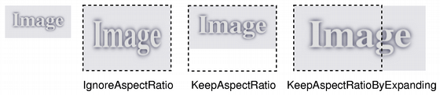

- If *aspectRatioMode* is Qt::IgnoreAspectRatio, the image is scaled to *size*.
- If *aspectRatioMode* is Qt::KeepAspectRatio, the image is scaled to a rectangle as large as possible inside *size*, preserving the aspect ratio.
- If *aspectRatioMode* is Qt::KeepAspectRatioByExpanding, the image is scaled to a rectangle as small as possible outside *size*, preserving the aspect ratio.

If the given *size* is empty, this function returns a null image.

**See also** isNull() and Image Transformations.

### QImage QImage::scaled(int *width*, int *height*, Qt::AspectRatioMode *aspectRatioMode* = Qt::IgnoreAspectRatio, Qt::TransformationMode *transformMode* = Qt::FastTransformation) const

This is an overloaded function.

Returns a copy of the image scaled to a rectangle with the given *width* and *height* according to the given *aspectRatioMode* and *transformMode*.

If either the *width* or the *height* is zero or negative, this function returns a null image.

### QImage QImage::scaledToHeight(int *height*, Qt::TransformationMode *mode* = Qt::FastTransformation) const

Returns a scaled copy of the image. The returned image is scaled to the given *height* using the specified transformation *mode*.

This function automatically calculates the width of the image so that the ratio of the image is preserved.

If the given *height* is 0 or negative, a null image is returned.

**See also** Image Transformations.

### QImage QImage::scaledToWidth(int *width*, Qt::TransformationMode *mode* = Qt::FastTransformation) const

Returns a scaled copy of the image. The returned image is scaled to the given *width* using the specified transformation *mode*.

This function automatically calculates the height of the image so that its aspect ratio is preserved.

If the given *width* is 0 or negative, a null image is returned.

**See also** Image Transformations.

### uchar *QImage::scanLine(int *i*)

Returns a pointer to the pixel data at the scanline with index *i*. The first scanline is at index 0.

The scanline data is as minimum 32-bit aligned. For 64-bit formats it follows the native alignment of 64-bit integers (64-bit for most platforms, but notably 32-bit on i386).

For example, to remove the green component of each pixel in an image:

```
for (int y = 0; y < image.height(); ++y) {
    QRgb *line = reinterpret_cast<QRgb*>(image.scanLine(y));
    for (int x = 0; x < image.width(); ++x) {
        QRgb &rgb = line[x];
        rgb = qRgba(qRed(rgb), qGreen(0), qBlue(rgb), qAlpha(rgb));
    }
}
```

**Warning:** If you are accessing 32-bpp image data, cast the returned pointer to `QRgb*` (QRgb has a 32-bit size) and use it to read/write the pixel value. You cannot use the `uchar*` pointer directly, because the pixel format depends on the byte order on the underlying platform. Use qRed(), qGreen(), qBlue(), and qAlpha() to access the pixels.

**See also** bytesPerLine(), bits(), Pixel Manipulation, and constScanLine().

### const uchar *QImage::scanLine(int *i*) const

This is an overloaded function.

### void QImage::setAlphaChannel(const QImage &*alphaChannel*)

Sets the alpha channel of this image to the given *alphaChannel*.

If *alphaChannel* is an 8 bit alpha image, the alpha values are used directly. Otherwise, *alphaChannel* is converted to 8 bit grayscale and the intensity of the pixel values is used.

If the image already has an alpha channel, the existing alpha channel is multiplied with the new one. If the image doesn't have an alpha channel it will be converted to a format that does.

The operation is similar to painting *alphaChannel* as an alpha image over this image using `QPainter::CompositionMode_DestinationIn`.

**See also** hasAlphaChannel(), Image Transformations, and Image Formats.

### void QImage::setColor(int *index*, QRgb *colorValue*)

Sets the color at the given *index* in the color table, to the given to *colorValue*. The color value is an ARGB quadruplet.

If *index* is outside the current size of the color table, it is expanded with setColorCount().

**See also** color(), colorCount(), setColorTable(), and Pixel Manipulation.

### void QImage::setColorCount(int *colorCount*)

Resizes the color table to contain *colorCount* entries.

If the color table is expanded, all the extra colors will be set to transparent (i.e qRgba(0, 0, 0, 0)).

When the image is used, the color table must be large enough to have entries for all the pixel/index values present in the image, otherwise the results are undefined.

**See also** colorCount(), colorTable(), setColor(), and Image Transformations.

### `[since 5.14]`void QImage::setColorSpace(const QColorSpace &*colorSpace*)

Sets the image color space to *colorSpace* without performing any conversions on image data.

This function was introduced in Qt 5.14.

**See also** colorSpace().

### void QImage::setColorTable(const QList<QRgb> &*colors*)

Sets the color table used to translate color indexes to QRgb values, to the specified *colors*.

When the image is used, the color table must be large enough to have entries for all the pixel/index values present in the image, otherwise the results are undefined.

**See also** colorTable(), setColor(), and Image Transformations.

### void QImage::setDevicePixelRatio(qreal *scaleFactor*)

Sets the device pixel ratio for the image. This is the ratio between image pixels and device-independent pixels.

The default *scaleFactor* is 1.0. Setting it to something else has two effects:

QPainters that are opened on the image will be scaled. For example, painting on a 200x200 image if with a ratio of 2.0 will result in effective (device-independent) painting bounds of 100x100.

Code paths in Qt that calculate layout geometry based on the image size will take the ratio into account: QSize layoutSize = image.size() / image.devicePixelRatio() The net effect of this is that the image is displayed as high-DPI image rather than a large image (see Drawing High Resolution Versions of Pixmaps and Images).

**See also** devicePixelRatio() and deviceIndependentSize().

### void QImage::setDotsPerMeterX(int *x*)

Sets the number of pixels that fit horizontally in a physical meter, to *x*.

Together with dotsPerMeterY(), this number defines the intended scale and aspect ratio of the image, and determines the scale at which QPainter will draw graphics on the image. It does not change the scale or aspect ratio of the image when it is rendered on other paint devices.

**See also** dotsPerMeterX() and Image Information.

### void QImage::setDotsPerMeterY(int *y*)

Sets the number of pixels that fit vertically in a physical meter, to *y*.

Together with dotsPerMeterX(), this number defines the intended scale and aspect ratio of the image, and determines the scale at which QPainter will draw graphics on the image. It does not change the scale or aspect ratio of the image when it is rendered on other paint devices.

**See also** dotsPerMeterY() and Image Information.

### void QImage::setOffset(const QPoint &*offset*)

Sets the number of pixels by which the image is intended to be offset by when positioning relative to other images, to *offset*.

**See also** offset() and Image Information.

### void QImage::setPixel(const QPoint &*position*, uint *index_or_rgb*)

Sets the pixel index or color at the given *position* to *index_or_rgb*.

If the image's format is either monochrome or paletted, the given *index_or_rgb* value must be an index in the image's color table, otherwise the parameter must be a QRgb value.

If *position* is not a valid coordinate pair in the image, or if *index_or_rgb* >= colorCount() in the case of monochrome and paletted images, the result is undefined.

**Warning:** This function is expensive due to the call of the internal `detach()` function called within; if performance is a concern, we recommend the use of scanLine() or bits() to access pixel data directly.

**See also** pixel() and Pixel Manipulation.

### void QImage::setPixel(int *x*, int *y*, uint *index_or_rgb*)

This is an overloaded function.

Sets the pixel index or color at (*x*, *y*) to *index_or_rgb*.

### `[since 5.6]`void QImage::setPixelColor(const QPoint &*position*, const QColor &*color*)

Sets the color at the given *position* to *color*.

If *position* is not a valid coordinate pair in the image, or the image's format is either monochrome or paletted, the result is undefined.

**Warning:** This function is expensive due to the call of the internal `detach()` function called within; if performance is a concern, we recommend the use of scanLine() or bits() to access pixel data directly.

This function was introduced in Qt 5.6.

**See also** pixelColor(), pixel(), bits(), scanLine(), and Pixel Manipulation.

### `[since 5.6]`void QImage::setPixelColor(int *x*, int *y*, const QColor &*color*)

This is an overloaded function.

Sets the pixel color at (*x*, *y*) to *color*.

This function was introduced in Qt 5.6.

### void QImage::setText(const QString &*key*, const QString &*text*)

Sets the image text to the given *text* and associate it with the given *key*.

If you just want to store a single text block (i.e., a "comment" or just a description), you can either pass an empty key, or use a generic key like "Description".

The image text is embedded into the image data when you call save() or QImageWriter::write().

Not all image formats support embedded text. You can find out if a specific image or format supports embedding text by using QImageWriter::supportsOption(). We give an example:

```
    QImageWriter writer;
    writer.setFormat("png");
    if (writer.supportsOption(QImageIOHandler::Description))
        qDebug() << "Png supports embedded text";
```

You can use QImageWriter::supportedImageFormats() to find out which image formats are available to you.

**See also** text() and textKeys().

### QSize QImage::size() const

Returns the size of the image, i.e. its width() and height().

**See also** Image Information and deviceIndependentSize().

### `[since 5.10]`qsizetype QImage::sizeInBytes() const

Returns the image data size in bytes.

This function was introduced in Qt 5.10.

**See also** bytesPerLine(), bits(), and Image Information.

### void QImage::swap(QImage &*other*)

Swaps image *other* with this image. This operation is very fast and never fails.

### QString QImage::text(const QString &*key* = QString()) const

Returns the image text associated with the given *key*. If the specified *key* is an empty string, the whole image text is returned, with each key-text pair separated by a newline.

**See also** setText() and textKeys().

### QStringList QImage::textKeys() const

Returns the text keys for this image.

You can use these keys with text() to list the image text for a certain key.

**See also** text().

### CGImageRef QImage::toCGImage() const

Creates a `CGImage` equivalent to this QImage.

Returns a `CGImageRef` handle.

The returned CGImageRef partakes in the QImage implicit sharing, and holds a reference to the QImage data. CGImage is immutable and will never detach the QImage. Writing to the QImage will detach as usual.

This function is fast, and does not copy or convert image data.

The following image formats are supported, and will be mapped to a corresponding native image type:

| Qt | CoreGraphics |
| --- | --- |
| Format_ARGB32 | kCGImageAlphaFirst \| kCGBitmapByteOrder32Host |
| Format_RGB32 | kCGImageAlphaNoneSkipFirst \| kCGBitmapByteOrder32Host |
| Format_RGBA8888_Premultiplied | kCGImageAlphaPremultipliedLast \| kCGBitmapByteOrder32Big |
| Format_RGBA8888 | kCGImageAlphaLast \| kCGBitmapByteOrder32Big |
| Format_RGBX8888 | kCGImageAlphaNoneSkipLast \| kCGBitmapByteOrder32Big |
| Format_ARGB32_Premultiplied | kCGImageAlphaPremultipliedFirst \| kCGBitmapByteOrder32Host |

Other formats are not supported; this function returns a null CGImageRef for those cases. Users of this function may then convert the QImage to a supported format first, for example Format_ARGB32_Premultiplied.

The CGImageRef color space is set to the sRGB color space.

### `[since 6.0]`HBITMAP QImage::toHBITMAP() const

Creates a `HBITMAP` equivalent of the QImage.

Returns the `HBITMAP` handle.

It is the caller's responsibility to free the `HBITMAP` data after use.

For usage with with standard GDI calls, such as `BitBlt()`, the image should have the format QImage::Format_RGB32.

When using the resulting HBITMAP for the `AlphaBlend()` GDI function, the image should have the format QImage::Format_ARGB32_Premultiplied (use convertToFormat()).

When using the resulting HBITMAP as application icon or a systray icon, the image should have the format QImage::Format_ARGB32.

This function was introduced in Qt 6.0.

**See also** fromHBITMAP() and convertToFormat().

### `[since 6.0]`HICON QImage::toHICON(const QImage &*mask* = {}) const

Creates a `HICON` equivalent of the QPixmap, applying the mask *mask*.

If *mask* is not null, it needs to be of format QImage::Format_Mono. Returns the `HICON` handle.

It is the caller's responsibility to free the `HICON` data after use.

This function was introduced in Qt 6.0.

**See also** fromHICON().

### `[static]`QImage::Format QImage::toImageFormat(QPixelFormat *format*)

Converts *format* into a QImage::Format

### `[static]`QPixelFormat QImage::toPixelFormat(QImage::Format *format*)

Converts *format* into a QPixelFormat

### QImage QImage::transformed(const QTransform &*matrix*, Qt::TransformationMode *mode* = Qt::FastTransformation) const

Returns a copy of the image that is transformed using the given transformation *matrix* and transformation *mode*.

The returned image will normally have the same {Image Formats}{format} as the original image. However, a complex transformation may result in an image where not all pixels are covered by the transformed pixels of the original image. In such cases, those background pixels will be assigned a transparent color value, and the transformed image will be given a format with an alpha channel, even if the original image did not have that.

The transformation *matrix* is internally adjusted to compensate for unwanted translation; i.e. the image produced is the smallest image that contains all the transformed points of the original image. Use the trueMatrix() function to retrieve the actual matrix used for transforming an image.

Unlike the other overload, this function can be used to perform perspective transformations on images.

**See also** trueMatrix() and Image Transformations.

### `[static]`QTransform QImage::trueMatrix(const QTransform &*matrix*, int *width*, int *height*)

Returns the actual matrix used for transforming an image with the given *width*, *height* and *matrix*.

When transforming an image using the transformed() function, the transformation matrix is internally adjusted to compensate for unwanted translation, i.e. transformed() returns the smallest image containing all transformed points of the original image. This function returns the modified matrix, which maps points correctly from the original image into the new image.

Unlike the other overload, this function creates transformation matrices that can be used to perform perspective transformations on images.

**See also** transformed() and Image Transformations.

### bool QImage::valid(const QPoint &*pos*) const

Returns `true` if *pos* is a valid coordinate pair within the image; otherwise returns `false`.

**See also** rect() and QRect::contains().

### bool QImage::valid(int *x*, int *y*) const

This is an overloaded function.

Returns `true` if QPoint(*x*, *y*) is a valid coordinate pair within the image; otherwise returns `false`.

### int QImage::width() const

Returns the width of the image.

**See also** Image Information.

### QVariant QImage::operator QVariant() const

Returns the image as a QVariant.

### bool QImage::operator!=(const QImage &*image*) const

Returns `true` if this image and the given *image* have different contents; otherwise returns `false`.

The comparison can be slow, unless there is some obvious difference, such as different widths, in which case the function will return quickly.

**See also** operator=().

### bool QImage::operator==(const QImage &*image*) const

Returns `true` if this image and the given *image* have the same contents; otherwise returns `false`.

The comparison can be slow, unless there is some obvious difference (e.g. different size or format), in which case the function will return quickly.

**See also** operator=().

## Related Non-Members

### `[since 5.0]`QImageCleanupFunction

A function with the following signature that can be used to implement basic image memory management:

```
void myImageCleanupHandler(void *info);
```

This typedef was introduced in Qt 5.0.

### QDataStream &operator<<(QDataStream &*stream*, const QImage &*image*)

Writes the given *image* to the given *stream* as a PNG image, or as a BMP image if the stream's version is 1. Note that writing the stream to a file will not produce a valid image file.

**See also** QImage::save() and Serializing Qt Data Types.

### QDataStream &operator>>(QDataStream &*stream*, QImage &*image*)

Reads an image from the given *stream* and stores it in the given *image*.

**See also** QImage::load() and Serializing Qt Data Types.

© The Qt Company Ltd  
Licensed under the GNU Free Documentation License, Version 1.3.  
https://doc.qt.io/qt-6.2/qimage.html